# Module 9 Assignment

Zachary Gonzalez

2022-03-23

Question 1

```r
library(multtest)
data(golub)
gol.fac <- factor(golub.cl, levels=0:1, labels = c("ALL", "AML"))
```

```r
grep("GRO2",golub.gnames[,2])
```

```
## [1] 2714
```

```r
grep("GRO3",golub.gnames[,2])
```

```
## [1] 2715
```

part a

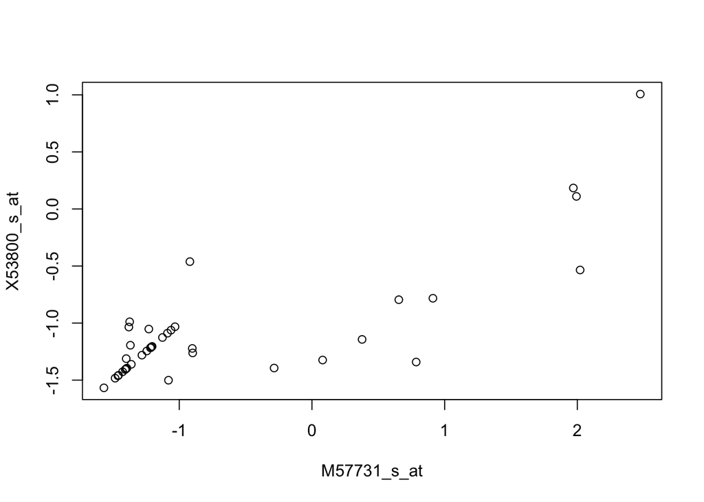

```r
x<-golub[2714,] #GRO2
y<-golub[2715,] #GRO3
plot(x,y,xlab=golub.gnames[2714,3],ylab=golub.gnames[2715,3]) #plot gene expressions
```

```r
cor(x,y) #calculate correlation between two genes
```

```
## [1] 0.7966283
```

part b - 90% parametric confidence interval

```r
cor.test(x, y, conf.level = 0.90)
```

```
##
##  Pearson's product-moment correlation
##
## data:  x and y
## t = 7.9074, df = 36, p-value = 2.201e-09
## alternative hypothesis: true correlation is not equal to 0
## 90 percent confidence interval:
##  0.6702984 0.8780861
## sample estimates:
##       cor
## 0.7966283
```

part c - 90% bootstrap confident interval

```r
nboot <- 2000
boot.cor <- matrix(0,nrow=nboot,ncol=1) #Vector to save re sampled statistic
data <- cbind(x,y)
for (i in 1:nboot){
  data.star <- data[sample(1:nrow(data),replace=TRUE),]
  boot.cor[i,] <- cor(data.star[,1], data.star[,2])
}
quantile(boot.cor[,1],c(0.05,0.95))
```

```
##        5%       95%
## 0.5868673 0.8991119
```

Question 2

```r
grep("Zyxin",golub.gnames[,2])
```

```
## [1] 2124
```

part a

```r
golub <- data.frame(golub)
zyxin_expression_cor <- apply(golub,1,cor, as.numeric(golub[2124,]))
cor.lessthan0.5 <- zyxin_expression_cor < 0.5
sum(cor.lessthan0.5)
```

```
## [1] 2941
```

part b

```r
order_genes <-order(zyxin_expression_cor)
golub.gnames[order_genes,][1:5,2]
```

```
## [1] "Macmarcks"
## [2] "Inducible protein mRNA"
## [3] "C-myb gene extracted from Human (c-myb) gene, complete primary cds, and five complete alternatively spliced cds"
## [4] "Oncoprotein 18 (Op18) gene"
## [5] "54 kDa protein mRNA"
```

part c

```r
golub <- data.frame(golub)
zyx_neg_cor <- apply(golub,1,function(x) cor.test(x, as.numeric(golub[2124,]), alternative = "less")$p.value)
p.fdrzyx <- p.adjust(p=zyx_neg_cor, method = "fdr")
sum(p.fdrzyx<0.05)
```

```
## [1] 142
```

Question 3

```r
GRO3 <- as.numeric(golub[2715,])
GRO2 <- as.numeric(golub[2714,])
lin.regGolub <- lm(GRO3 ~ GRO2)
lin.regGolub
```

```
##
## Call:
## lm(formula = GRO3 ~ GRO2)
##
## Coefficients:
## (Intercept)         GRO2
##     -0.8426       0.3582
```

part a

```r
cor.test(GRO3, GRO2)
```

```
##
##  Pearson's product-moment correlation
##
## data:  GRO3 and GRO2
## t = 7.9074, df = 36, p-value = 2.201e-09
## alternative hypothesis: true correlation is not equal to 0
## 95 percent confidence interval:
##  0.6399101 0.8897262
## sample estimates:
##       cor
## 0.7966283
```

We can see from the pearson’s product-moment correlation test, there is a moderately strong positive linear relationship between the expression values of the genes. This is evident from the rather large R value of around 0.8 and the very small p-value of 2.2*10^-9

```r
summary(lin.regGolub)
```

```
##
## Call:
## lm(formula = GRO3 ~ GRO2)
##
## Residuals:
##      Min       1Q   Median       3Q      Max
## -0.78038 -0.10639 -0.00553  0.14225  0.96298
##
## Coefficients:
##             Estimate Std. Error t value Pr(>|t|)
## (Intercept) -0.84256    0.05941 -14.182 2.62e-16 ***
## GRO2         0.35820    0.04530   7.907 2.20e-09 ***
## ---
## Signif. codes:  0 '***' 0.001 '**' 0.01 '*' 0.05 '.' 0.1 ' ' 1
##
## Residual standard error: 0.3201 on 36 degrees of freedom
## Multiple R-squared:  0.6346, Adjusted R-squared:  0.6245
## F-statistic: 62.53 on 1 and 36 DF,  p-value: 2.201e-09
```

63.46% of the GRO3 expression variation can be explained by regression on GRO2 expression.

part b

```r
confint(lin.regGolub, level = 0.9)
```

```
##                    5 %       95 %
## (Intercept) -0.9428580 -0.7422600
## GRO2         0.2817217  0.4346801
```

The slope parameter is less than 0.5 at the alpha 5% (0.05) level

part c

```r
predict(lin.regGolub, newdata=data.frame(GRO2=0), interval = "prediction", level = 0.80)
```

```
##         fit       lwr        upr
## 1 -0.842559 -1.267563 -0.4175553
```

part d

```r
shapiro.test(resid(lin.regGolub))
```

```
##
##  Shapiro-Wilk normality test
##
## data:  resid(lin.regGolub)
## W = 0.94779, p-value = 0.07532
```

p-value is greater than 0.05 thus we fail to reject the null hypothesis of normality. The assumption for normality holds and we can trust the inferences from the regression fit

Question 4

```r
data("stackloss")
```

part a

```r
lin.reg <- lm(stack.loss~Air.Flow+Water.Temp+Acid.Conc.,data = stackloss)
summary(lin.reg)
```

```
##
## Call:
## lm(formula = stack.loss ~ Air.Flow + Water.Temp + Acid.Conc.,
##     data = stackloss)
##
## Residuals:
##     Min      1Q  Median      3Q     Max
## -7.2377 -1.7117 -0.4551  2.3614  5.6978
##
## Coefficients:
##             Estimate Std. Error t value Pr(>|t|)
## (Intercept) -39.9197    11.8960  -3.356  0.00375 **
## Air.Flow      0.7156     0.1349   5.307  5.8e-05 ***
## Water.Temp    1.2953     0.3680   3.520  0.00263 **
## Acid.Conc.   -0.1521     0.1563  -0.973  0.34405
## ---
## Signif. codes:  0 '***' 0.001 '**' 0.01 '*' 0.05 '.' 0.1 ' ' 1
##
## Residual standard error: 3.243 on 17 degrees of freedom
## Multiple R-squared:  0.9136, Adjusted R-squared:  0.8983
## F-statistic:  59.9 on 3 and 17 DF,  p-value: 3.016e-09
```

fitted regression equation: Stack.Loss = -39.92 +0.72Air.FLow + 1.30Water.Temp -0.15Acid.Conc.

part b

No, not all three variables have a statistically significant effect on stack loss. Air flow and water temperature do but acid concentration does not. Together the variables explain 91.36% of total variation in stack loss.

part c - 90% confidence and prediction intervals

```r
predict(lin.reg, data.frame(Air.Flow=60,Water.Temp=20,Acid.Conc.=90),interval = "confidence", level = 0.90)
```

```
##        fit      lwr      upr
## 1 15.23343 13.50069 16.96617
```

```r
predict(lin.reg, data.frame(Air.Flow=60,Water.Temp=20,Acid.Conc.=90),interval = "prediction", level = 0.90)
```

```
##        fit      lwr      upr
## 1 15.23343 9.331184 21.13568
```